# Red Wine Quality Analysis

by Alivelu Duvvuri

=======================================================

### About Redwine

As we are interested in the best quality of wine, First I will analyze the Redwine Dataset and then I will try to understand the factors responsible.

### What is Exploratory Data Analysis

- Examination of data and relationships among variables through numerical and graphical methods.
- Often takes place before more formal/rigorous statistical analysis.
- Major opportunity to check against bad data.

This is really your initial interaction with the data and integral with the data wrangling process.

```
## [1] "C:/Users/alive/Documents/Data Analyst Nano Degree/exploratory dataanalysis"
```

** If above directory is not where your project files are located, then change or set the working directory **

** Check if the working directorty is changed according to your given location **

```
## [1] "C:/Users/alive/Documents/Data Analyst Nano Degree/exploratory dataanalysis"
```

** As the directory is changed **

```
##  [1] "__MACOSX"                    "exploraoryprojectfinal8.Rmd"
##  [3] "lesson2"                     "lesson3"
##  [5] "lesson4"                     "lesson5"
##  [7] "lesson6"                     "New folder"
##  [9] "Week_10_Workbook"            "Week_11_Workbook"
## [11] "Week_11_Workbook.zip"        "Week_9_Workbook"
## [13] "What_is_a_RMD_file.Rmd"      "wineQualityReds.csv"
```

The resulting object is a dataframe, just like in pandas

In fact, pandas dataframes are based on the idea of Dataframes from R

```
## [1] TRUE
```

```
##   X fixed.acidity volatile.acidity citric.acid residual.sugar chlorides
## 1 1           7.4             0.70        0.00            1.9     0.076
## 2 2           7.8             0.88        0.00            2.6     0.098
## 3 3           7.8             0.76        0.04            2.3     0.092
## 4 4          11.2             0.28        0.56            1.9     0.075
## 5 5           7.4             0.70        0.00            1.9     0.076
## 6 6           7.4             0.66        0.00            1.8     0.075
##   free.sulfur.dioxide total.sulfur.dioxide density   pH sulphates alcohol
## 1                  11                   34  0.9978 3.51      0.56     9.4
## 2                  25                   67  0.9968 3.20      0.68     9.8
## 3                  15                   54  0.9970 3.26      0.65     9.8
## 4                  17                   60  0.9980 3.16      0.58     9.8
## 5                  11                   34  0.9978 3.51      0.56     9.4
## 6                  13                   40  0.9978 3.51      0.56     9.4
##   quality
## 1       5
## 2       5
## 3       5
## 4       6
## 5       5
## 6       5
```

It is a tidy dataset, we don’t need data wrangling.

As the libraries are already imported, let’s explore the relationship between variables

From the above we understood that X is just an id and it’s not useful to us in our analysis

```
## [1] 1599   13
```

```
## [1] 1599
```

```
## [1] 13
```

This dataset is about quality of wine. There are 1599 samples of wine.

Total 13 variables.

```
##  [1] "X"                    "fixed.acidity"        "volatile.acidity"
##  [4] "citric.acid"          "residual.sugar"       "chlorides"
##  [7] "free.sulfur.dioxide"  "total.sulfur.dioxide" "density"
## [10] "pH"                   "sulphates"            "alcohol"
## [13] "quality"
```

** By looking at the above names of the variables or columns we can say that they are chemical components of the wine and it’s quality **

** After looking at above variables, I can say that quality is the main feature. **

### Univariate Analysis?

Univariate analysis is the simplest form of analyzing data. “Uni” means “one”, so in other words your data has only one variable. It doesn’t deal with causes or relationships (unlike regression) and it’s major purpose is to describe; it takes data, summarizes that data and finds patterns in the data.

A variable in univariate analysis is just a condition or subset that your data falls into. You can think of it as a “category.” For example, the analysis might look at a variable of “age” or it might look at “height” or “weight”. However, it doesn’t look at more than one variable at a time otherwise it becomes bivariate analysis (or in the case of 3 or more variables it would be called multivariate analysis).

Some ways you can describe patterns found in univariate data include central tendency (mean, mode and median) and dispersion: range, variance, maximum, minimum, quartiles (including the interquartile range), and standard deviation

- ggplot() used to give basic logistics of the plot input.
- geom_density() is used for checking the distribution of variable over x axis.
- gtitle() used to give title to plot.

# Let’s look at summary

```
##        X          fixed.acidity   volatile.acidity  citric.acid
##  Min.   :   1.0   Min.   : 4.60   Min.   :0.1200   Min.   :0.000
##  1st Qu.: 400.5   1st Qu.: 7.10   1st Qu.:0.3900   1st Qu.:0.090
##  Median : 800.0   Median : 7.90   Median :0.5200   Median :0.260
##  Mean   : 800.0   Mean   : 8.32   Mean   :0.5278   Mean   :0.271
##  3rd Qu.:1199.5   3rd Qu.: 9.20   3rd Qu.:0.6400   3rd Qu.:0.420
##  Max.   :1599.0   Max.   :15.90   Max.   :1.5800   Max.   :1.000
##  residual.sugar     chlorides       free.sulfur.dioxide
##  Min.   : 0.900   Min.   :0.01200   Min.   : 1.00
##  1st Qu.: 1.900   1st Qu.:0.07000   1st Qu.: 7.00
##  Median : 2.200   Median :0.07900   Median :14.00
##  Mean   : 2.539   Mean   :0.08747   Mean   :15.87
##  3rd Qu.: 2.600   3rd Qu.:0.09000   3rd Qu.:21.00
##  Max.   :15.500   Max.   :0.61100   Max.   :72.00
##  total.sulfur.dioxide    density             pH          sulphates
##  Min.   :  6.00       Min.   :0.9901   Min.   :2.740   Min.   :0.3300
##  1st Qu.: 22.00       1st Qu.:0.9956   1st Qu.:3.210   1st Qu.:0.5500
##  Median : 38.00       Median :0.9968   Median :3.310   Median :0.6200
##  Mean   : 46.47       Mean   :0.9967   Mean   :3.311   Mean   :0.6581
##  3rd Qu.: 62.00       3rd Qu.:0.9978   3rd Qu.:3.400   3rd Qu.:0.7300
##  Max.   :289.00       Max.   :1.0037   Max.   :4.010   Max.   :2.0000
##     alcohol         quality
##  Min.   : 8.40   Min.   :3.000
##  1st Qu.: 9.50   1st Qu.:5.000
##  Median :10.20   Median :6.000
##  Mean   :10.42   Mean   :5.636
##  3rd Qu.:11.10   3rd Qu.:6.000
##  Max.   :14.90   Max.   :8.000
```

** Now we have the table **

In the above table for each of the variable in the dataset, we will get the statistics like min, maximum. median, mean etc.

Density, pH, Alcohol and Quality are looking normal.

Remaining variables are having a huge difference in the third quartile value and maximum value.

** For example **

- Citric.acid
- Min. :0.000 3rd Qu.: 0.42 Max. :1.000
- Residual.sugar  
  #*Min. : 0.900 3rd Qu.: 2.600 Max. :15.500

```
## [1] 0
```

```
## [1] "No, missing value or null values"
```

```
##  [1] X                    fixed.acidity        volatile.acidity
##  [4] citric.acid          residual.sugar       chlorides
##  [7] free.sulfur.dioxide  total.sulfur.dioxide density
## [10] pH                   sulphates            alcohol
## [13] quality
## <0 rows> (or 0-length row.names)
```

```
##  [1] X                    fixed.acidity        volatile.acidity
##  [4] citric.acid          residual.sugar       chlorides
##  [7] free.sulfur.dioxide  total.sulfur.dioxide density
## [10] pH                   sulphates            alcohol
## [13] quality
## <0 rows> (or 0-length row.names)
```

```
##    Min. 1st Qu.  Median    Mean 3rd Qu.    Max.
##   3.000   5.000   6.000   5.636   6.000   8.000
```

Quality ranges from 3 to 8.

```
## [1] 9012
```

```
## [1] 0.6521684
```

```
## [1] 0.8075694
```

So let’s plot and understand

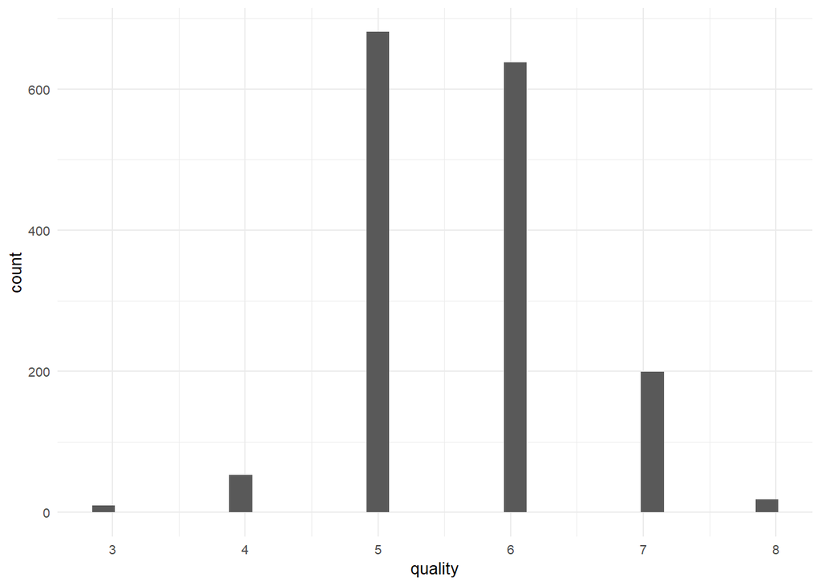

bin 5 & 6 Quality wines are more in number

Wine quality 5 is more in number

Quality range is in between 3-8

Generally grade should be in between 0 - 10. This means out of 11 grades we have only 6 grades of wines are available. i.e 54.55% quality of wines available. So we are predicting based on 55% of avaiability.

** Add titles and modify binwidth **

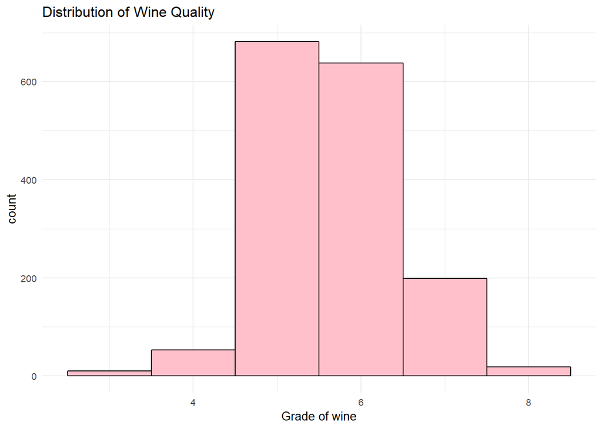

We can say that quality has normal distribution

```
## 'data.frame':    1599 obs. of  13 variables:
##  $ X                   : int  1 2 3 4 5 6 7 8 9 10 ...
##  $ fixed.acidity       : num  7.4 7.8 7.8 11.2 7.4 7.4 7.9 7.3 7.8 7.5 ...
##  $ volatile.acidity    : num  0.7 0.88 0.76 0.28 0.7 0.66 0.6 0.65 0.58 0.5 ...
##  $ citric.acid         : num  0 0 0.04 0.56 0 0 0.06 0 0.02 0.36 ...
##  $ residual.sugar      : num  1.9 2.6 2.3 1.9 1.9 1.8 1.6 1.2 2 6.1 ...
##  $ chlorides           : num  0.076 0.098 0.092 0.075 0.076 0.075 0.069 0.065 0.073 0.071 ...
##  $ free.sulfur.dioxide : num  11 25 15 17 11 13 15 15 9 17 ...
##  $ total.sulfur.dioxide: num  34 67 54 60 34 40 59 21 18 102 ...
##  $ density             : num  0.998 0.997 0.997 0.998 0.998 ...
##  $ pH                  : num  3.51 3.2 3.26 3.16 3.51 3.51 3.3 3.39 3.36 3.35 ...
##  $ sulphates           : num  0.56 0.68 0.65 0.58 0.56 0.56 0.46 0.47 0.57 0.8 ...
##  $ alcohol             : num  9.4 9.8 9.8 9.8 9.4 9.4 9.4 10 9.5 10.5 ...
##  $ quality             : int  5 5 5 6 5 5 5 7 7 5 ...
```

Let’s plot each of the variable. Based on the distribution shape( Normal, Positive Skew or Negative Skew), we can understand the expected behavior of different variables.

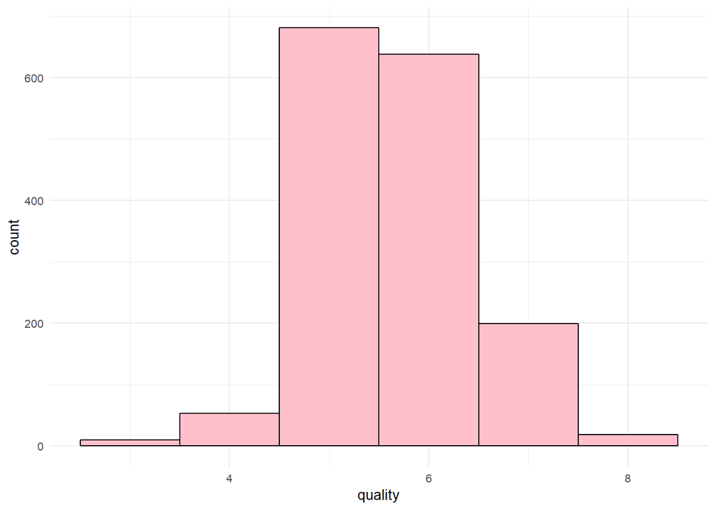

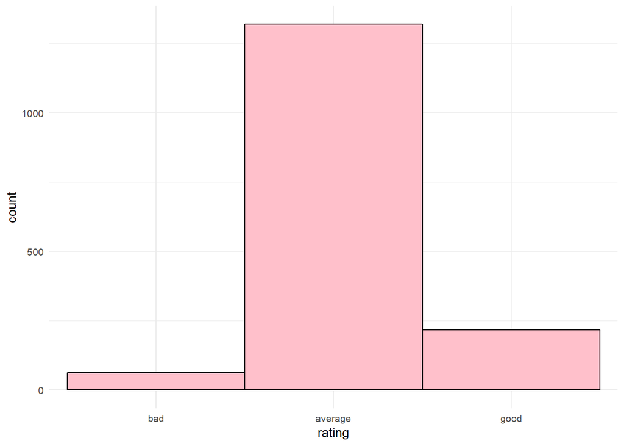

One thing I am seeing from the above two plots is most of the wines in the dataset are average quality wines. So I am wondering whether this data collected is accurate or complete or not. Was this data collected from a specific geographical location? Or was it spread around a big area? As the good quality and the poor quality wines are almost like outliers here, it might be difficult to get an accurate model of the Wine Quality. Let’s look at the other plots.

```
## 'data.frame':    1599 obs. of  15 variables:
##  $ X                   : int  1 2 3 4 5 6 7 8 9 10 ...
##  $ fixed.acidity       : num  7.4 7.8 7.8 11.2 7.4 7.4 7.9 7.3 7.8 7.5 ...
##  $ volatile.acidity    : num  0.7 0.88 0.76 0.28 0.7 0.66 0.6 0.65 0.58 0.5 ...
##  $ citric.acid         : num  0 0 0.04 0.56 0 0 0.06 0 0.02 0.36 ...
##  $ residual.sugar      : num  1.9 2.6 2.3 1.9 1.9 1.8 1.6 1.2 2 6.1 ...
##  $ chlorides           : num  0.076 0.098 0.092 0.075 0.076 0.075 0.069 0.065 0.073 0.071 ...
##  $ free.sulfur.dioxide : num  11 25 15 17 11 13 15 15 9 17 ...
##  $ total.sulfur.dioxide: num  34 67 54 60 34 40 59 21 18 102 ...
##  $ density             : num  0.998 0.997 0.997 0.998 0.998 ...
##  $ pH                  : num  3.51 3.2 3.26 3.16 3.51 3.51 3.3 3.39 3.36 3.35 ...
##  $ sulphates           : num  0.56 0.68 0.65 0.58 0.56 0.56 0.46 0.47 0.57 0.8 ...
##  $ alcohol             : num  9.4 9.8 9.8 9.8 9.4 9.4 9.4 10 9.5 10.5 ...
##  $ quality             : int  5 5 5 6 5 5 5 7 7 5 ...
##  $ quality_fac         : Factor w/ 6 levels "3","4","5","6",..: 3 3 3 4 3 3 3 5 5 3 ...
##  $ rating              : Ord.factor w/ 3 levels "bad"<"average"<..: 2 2 2 2 2 2 2 3 3 2 ...
```

```
## [1] "3" "4" "5" "6" "7" "8"
```

```
## [1] "bad"     "average" "good"
```

```
## [1] 10.42298
```

```
## [1] 14.9
```

```
## [1] 10.2
```

```
## [1] 8.4
```

```
## [1] 16666.35
```

```
## [1] 1.135647
```

```
## [1] 1.065668
```

```
##    Min. 1st Qu.  Median    Mean 3rd Qu.    Max.
##    8.40    9.50   10.20   10.42   11.10   14.90
```

Third quartile is 11.1%.

Median score of alcohol is 10.2%

Mean value is 10.42%

So from above alcohol content is in between 8 and 15

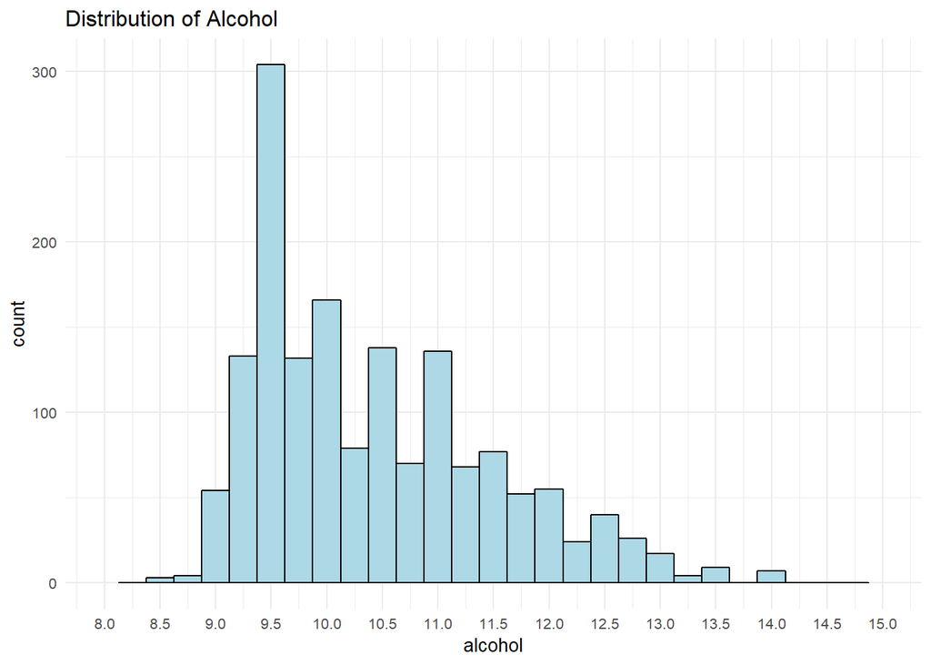

From the above we can say that alcohol content around 9.5 are more in number

Mean 10.42 is greater than median 10.2 . So oi is Positively skewed

From the above graph, we can say that alcohol rate is right skewed,

As the third quartile is 11.1%, I.e most of the wines in the redwine data set have an alcohol rate less than 11.1% and only 25% of the red wines have an alcohol rate above 11.1%

```
##    Min. 1st Qu.  Median    Mean 3rd Qu.    Max.
##   2.740   3.210   3.310   3.311   3.400   4.010
```

Mean and median are neraly same. So most of the wine can be at the level of 3.31 pH Most acidic wine has pH value of 2.74

```
## [1] 5294.47
```

```
## [1] 0.02383518
```

```
## [1] 0.1543865
```

From the above pH values are in between 2.5 and 4.5

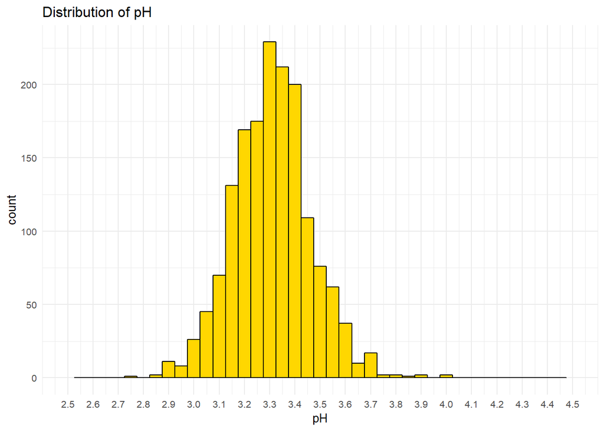

From the above we can understand that pH between 3.25 and 3.45 are more in number It’s a normal distribution

```
##    Min. 1st Qu.  Median    Mean 3rd Qu.    Max.
##  0.9901  0.9956  0.9968  0.9967  0.9978  1.0037
```

Mean equals to 0.9967 and median equals to 0.9968.

```
## [1] 1593.798
```

```
## [1] 3.562029e-06
```

```
## [1] 0.001887334
```

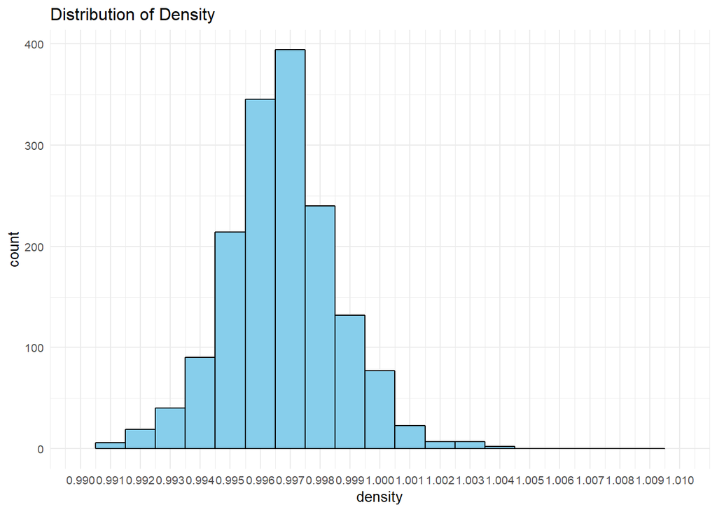

Density between 0.996 and 0.9975 wines are more

It’s a normal distribution

After looking at summary and graph we can say that 1.0037 is outlier

```
##    Min. 1st Qu.  Median    Mean 3rd Qu.    Max.
##  0.3300  0.5500  0.6200  0.6581  0.7300  2.0000
```

Mean 0.6581 is greater than Median 0.62

```
## [1] 1052.38
```

```
## [1] 0.02873262
```

```
## [1] 0.169507
```

From the above we can understand that sulphate content is in between 0.3 and 2

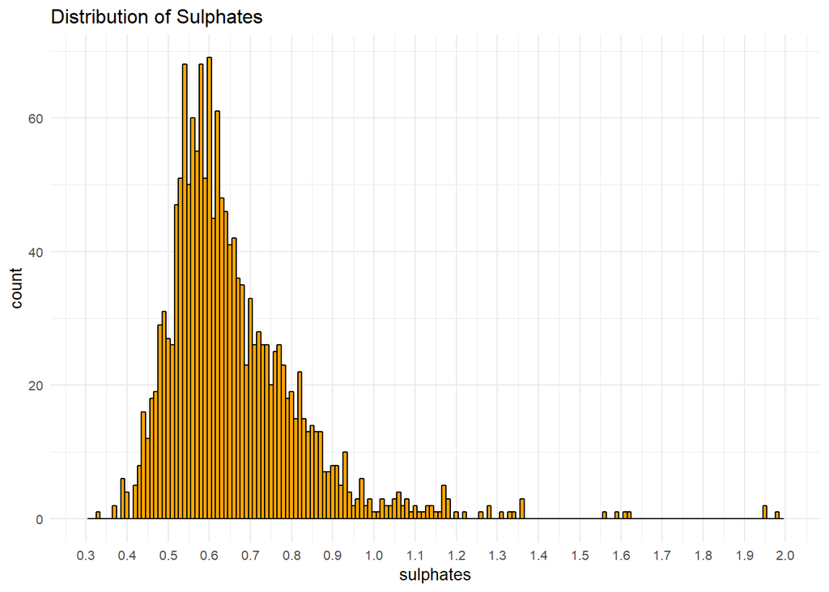

In between Sulphate content of 0.5 and 0.65 more wines are there

Mean 0.6581 is greater than Median 0.62. So it is positively skewed

It has long tail on right

```
##    Min. 1st Qu.  Median    Mean 3rd Qu.    Max.
##    4.60    7.10    7.90    8.32    9.20   15.90
```

Fixed acidity values are in beween 4.6 and 15.9 Mean 8.32 is greater than Median 7.9

```
## [1] 13303.1
```

```
## [1] 3.031416
```

```
## [1] 1.741096
```

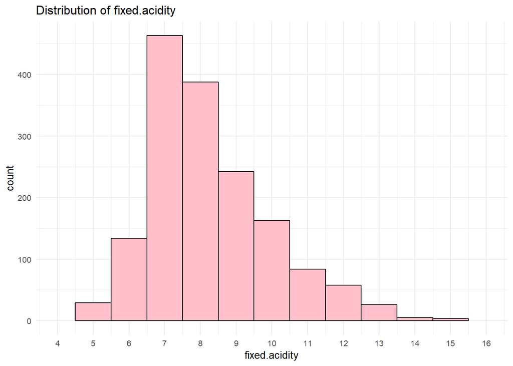

Mean 8.32 is greater than Median 7.9, So it’s poistively skewed

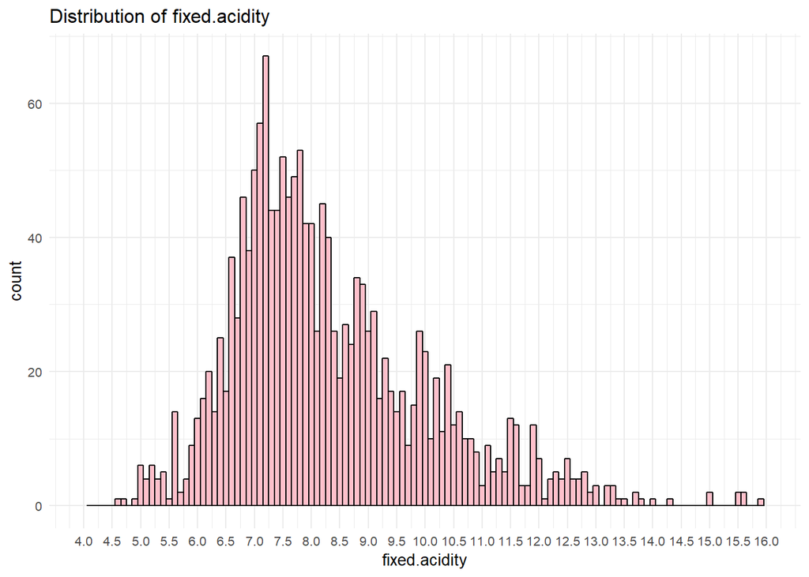

In between 6.75 to 7.25 values of fixed.acidity more wines are there

Looks like it has little right tail

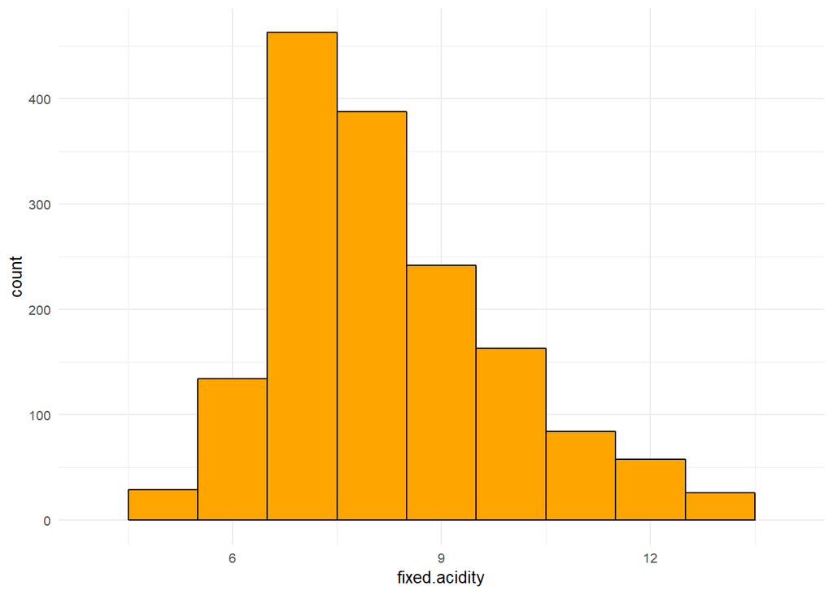

```
##    Min. 1st Qu.  Median    Mean 3rd Qu.    Max.
##  0.1200  0.3900  0.5200  0.5278  0.6400  1.5800
```

Volatile acidity is in between 0.12 and 1.58

Mean 0.5278 is slightly greater than Median 0.52 g/dm3

```
## [1] 843.985
```

```
## [1] 0.03206238
```

```
## [1] 0.1790597
```

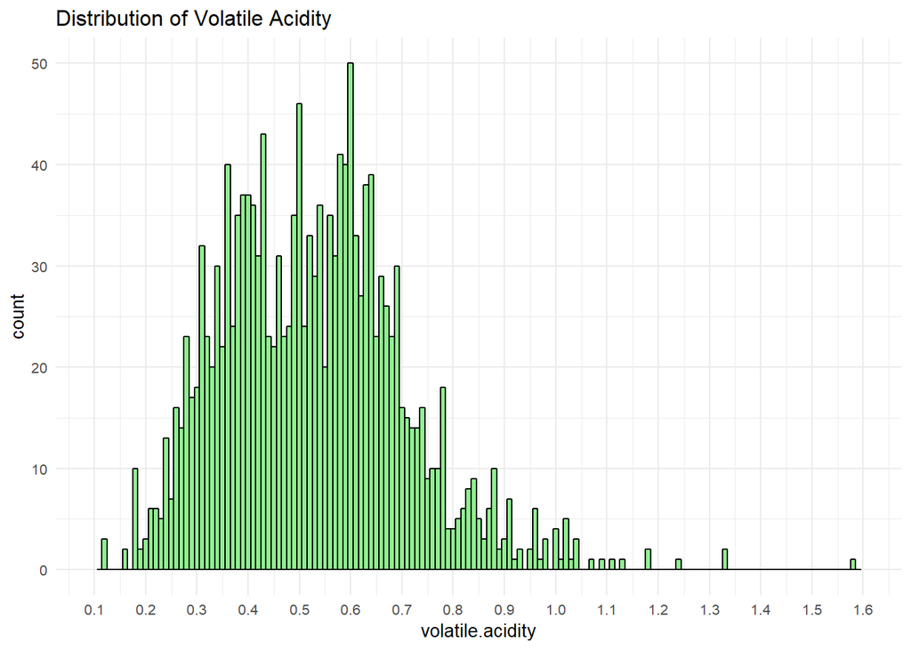

It’s not very clear but in between 0.3 and 0.7 volatile acidity more wines present.

It’s a plot with normal distribution. But there is small tail on the right side

Mean 0.5278 is slightly greater than Median 0.52 g/dm3. So it is slightly positively skewed

High acidity can lead to unpleasant taste.

** Let’s have closer look **

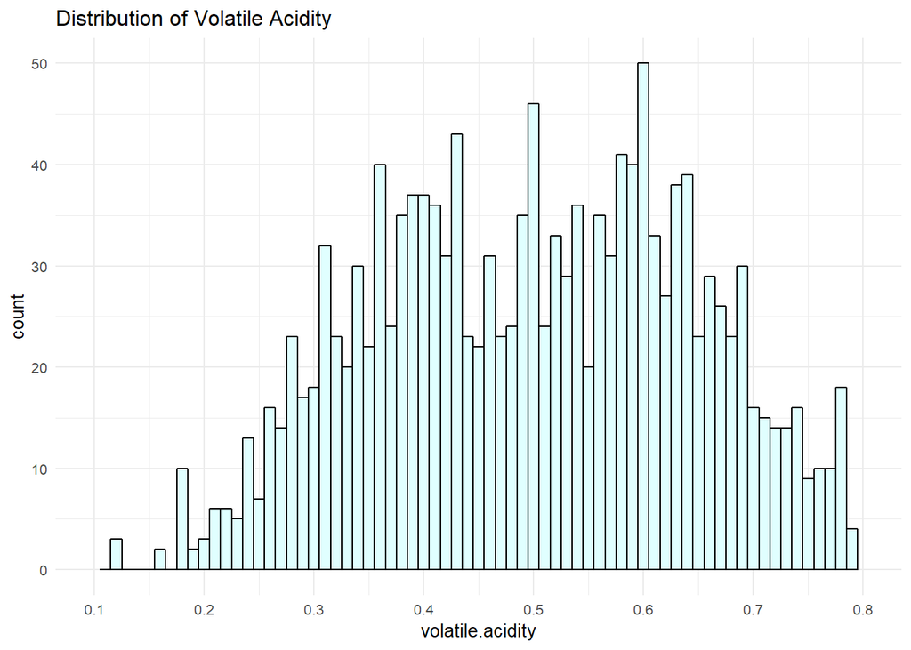

Looks like more wines are around volatile acidity of 0.58 and 0.6

```
##    Min. 1st Qu.  Median    Mean 3rd Qu.    Max.
##   0.000   0.090   0.260   0.271   0.420   1.000
```

From the above it’s understood that minimum value of citric acid is 0 and maximum value is 1.

Mean 0.271 is slightly greater than median 0.26.

```
## [1] 433.29
```

```
## [1] 0.03794748
```

```
## [1] 0.1948011
```

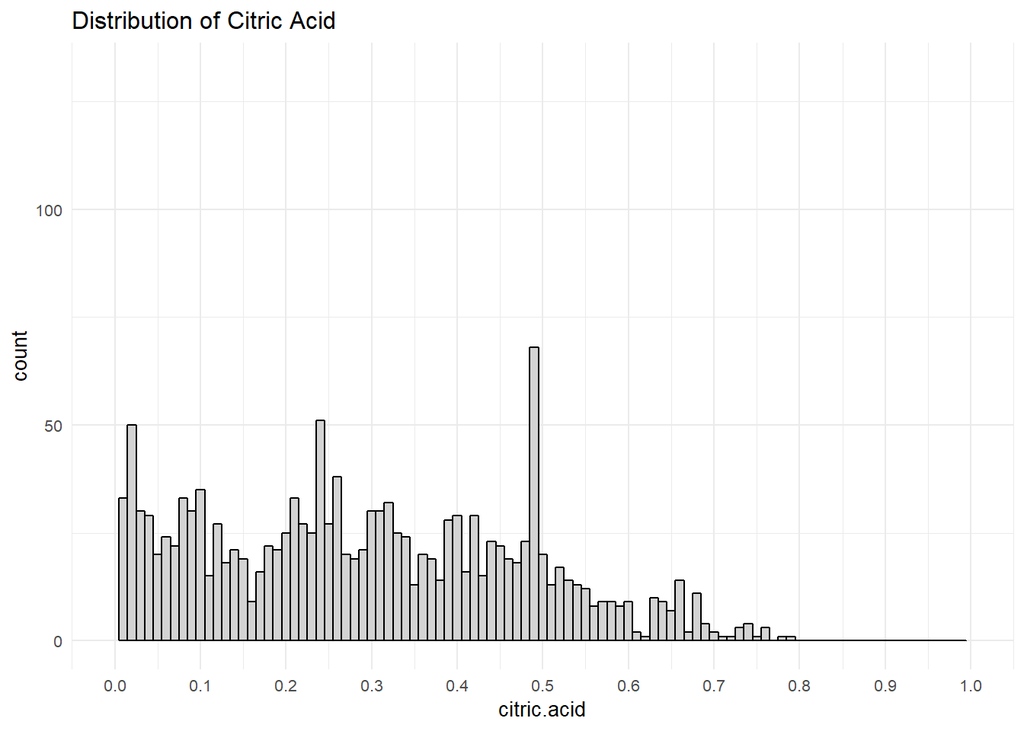

In between 0.475 and 0.5 value of citric acid more wines are present

By looking at the pot its hard to say about distribution

I can see 3 main peaks

- between 0 and 0.05
- Around 0.25
- Around 0.5

```
##    Min. 1st Qu.  Median    Mean 3rd Qu.    Max.
##   0.900   1.900   2.200   2.539   2.600  15.500
```

Third quartile value of 2.6 is indicating that 75% of wines have a residual sugar value of below 2.6 g/dm3. That means remaining 25 % have values in between 2.6 and 15.5 Mean 2.539 is slightly greater than Median 2.2

```
## [1] 4059.55
```

```
## [1] 1.987897
```

```
## [1] 1.409928
```

From the above we understood that min value of residual sugar is 0.9 and max 15.5

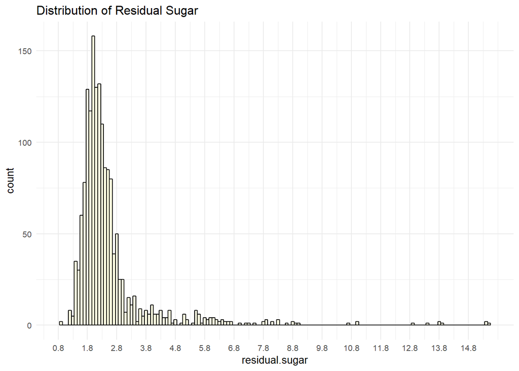

Between 1.8 and 2.3 value of residual sugar more wines are present.

Very Long tail on right side

Mean 2.539 is slightly greater than Median 2.2, so it is positively skewed

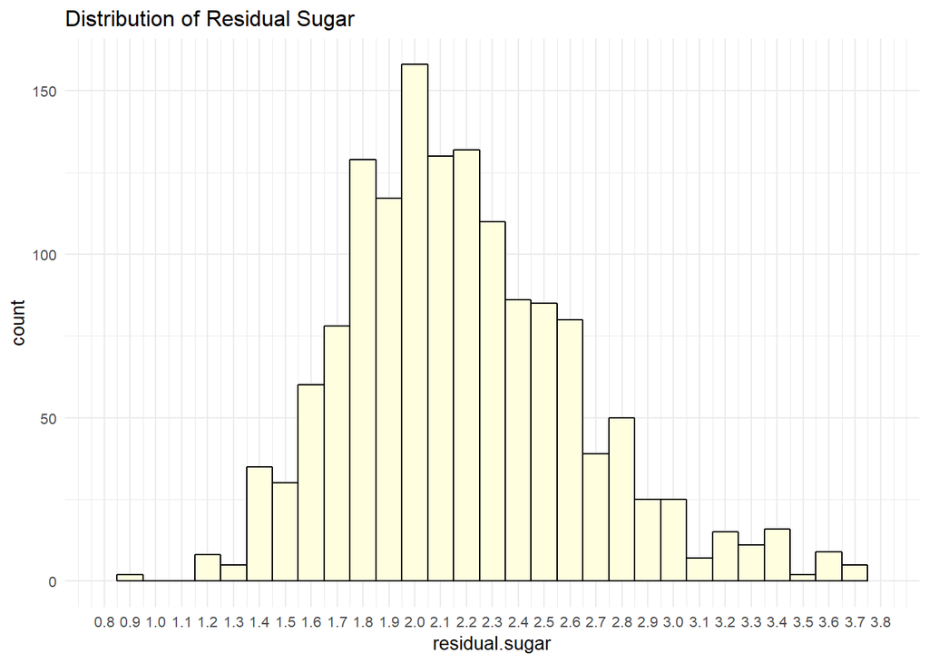

Between 1.95 and 2.05 value of residual sugar more wines are present

```
##    Min. 1st Qu.  Median    Mean 3rd Qu.    Max.
## 0.01200 0.07000 0.07900 0.08747 0.09000 0.61100
```

From the above we understood that in between 0.01 and 0.62 vales of chloride more wines are present

As the third quartile is 0.09. 75% of wines are beloww 0.09 . So clearly 0.61 is an outlier

```
## [1] 139.859
```

```
## [1] 0.002215143
```

```
## [1] 0.0470653
```

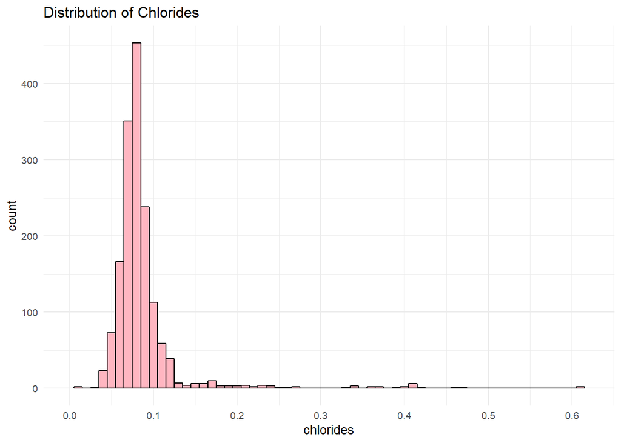

Normally distributed, but long tail distribution on right side

Tail is starting from 0.15

75% of wines are below 0.09

So only 25% odf wines are above 0.09

** Let’s look little closer **

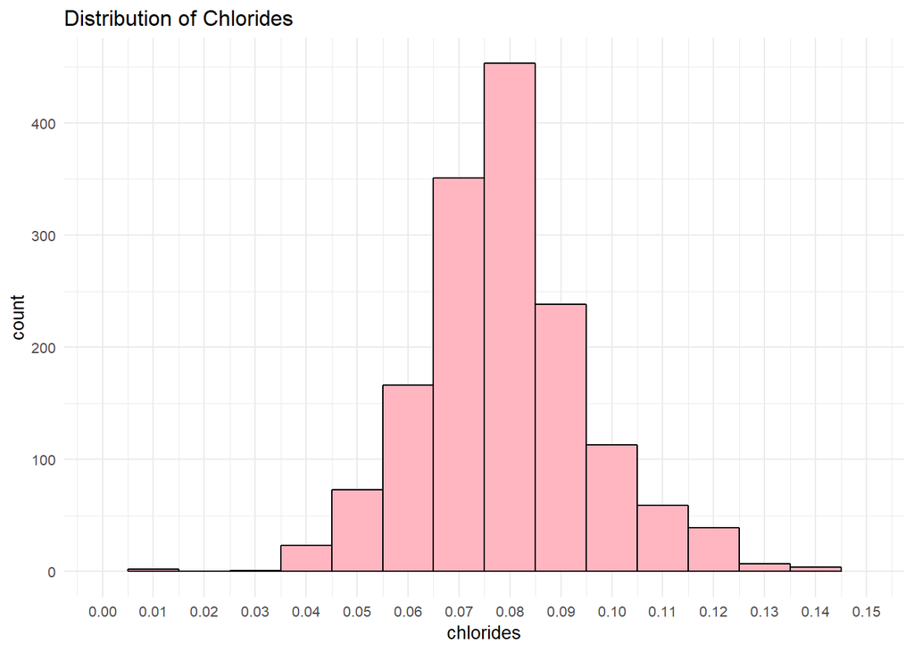

So in between 0.075 and 0.085 values of chlorides more wines are present.

```
##    Min. 1st Qu.  Median    Mean 3rd Qu.    Max.
##    1.00    7.00   14.00   15.87   21.00   72.00
```

Value of free sulfur dioxide is in between 1.0 and 72

75% of values are below 21 mg/dm3

Mean 15.87 is greater than Median 14.0

```
## [1] 25384
```

```
## [1] 109.4149
```

```
## [1] 10.46016
```

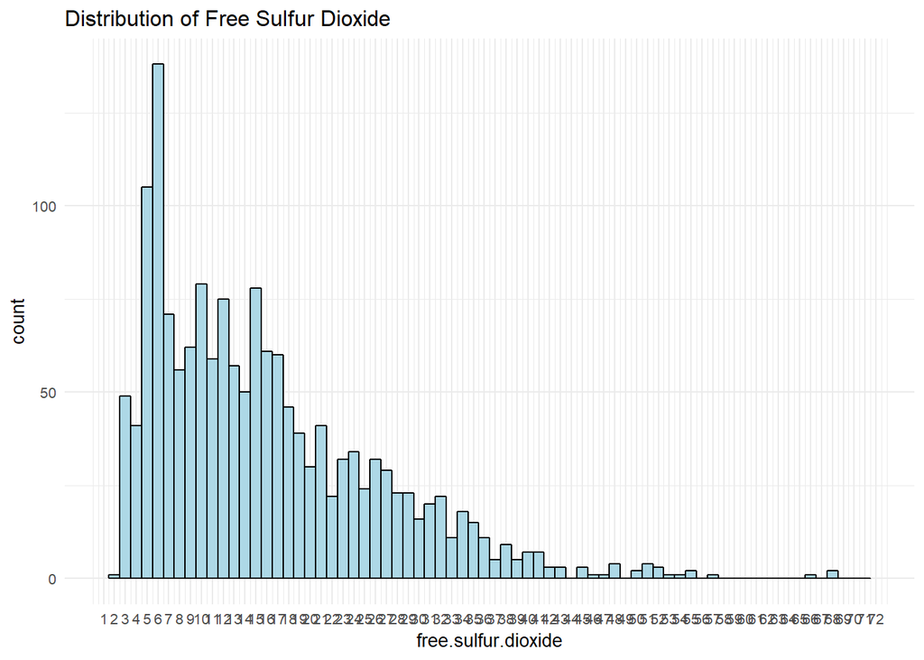

Mean 15.87 is greater than Median 14.0, So Right tailed distribution

** Let’s have closer look **

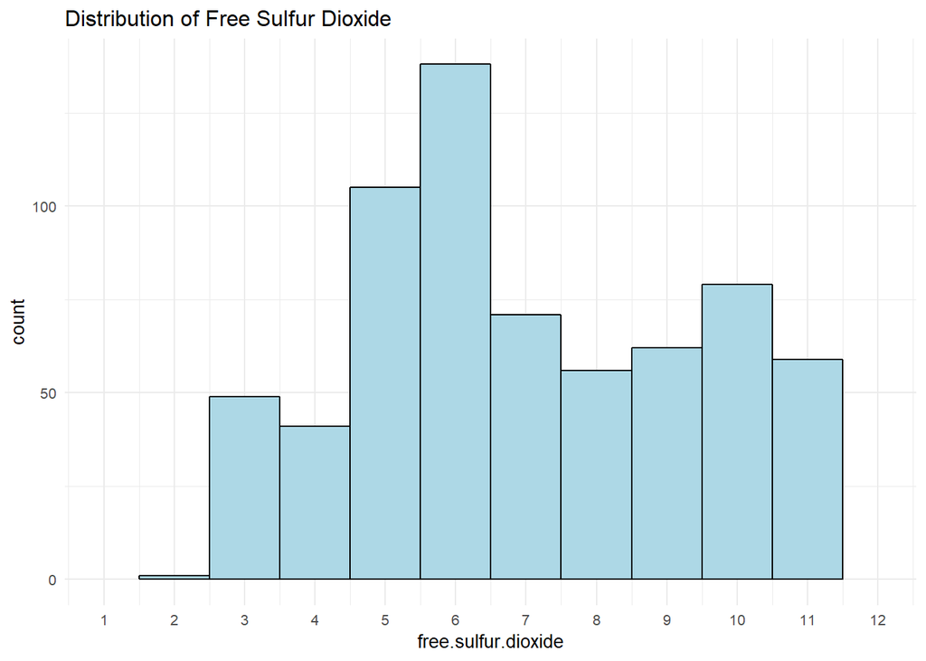

In between 5.5 and 6.5 values of free sulfur dioxide more wines are present.

```
##    Min. 1st Qu.  Median    Mean 3rd Qu.    Max.
##    6.00   22.00   38.00   46.47   62.00  289.00
```

From the above we can say that total sulfur dioxide values are in between 6.0 and 289

75% of the wines in redwine dataset has a sulfur dioxide value below 62

Mean 46.47 is greater than 38.0, so positively skewed

```
## [1] 74302
```

```
## [1] 1082.102
```

```
## [1] 32.89532
```

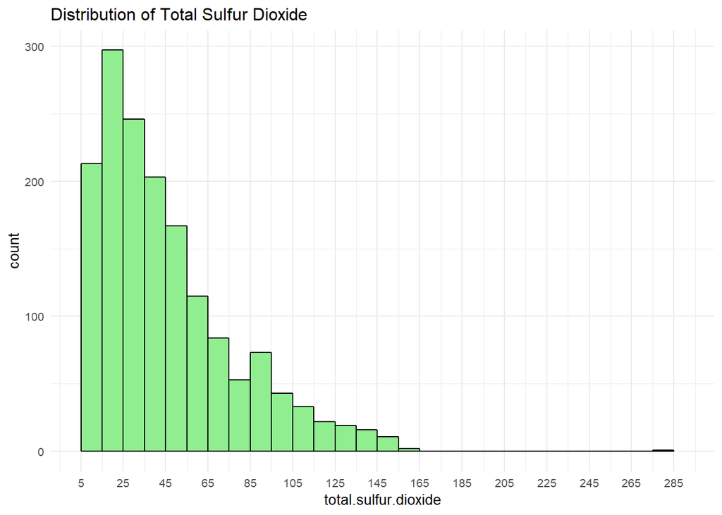

Between 15 and 25 values of sulfur dioxide more wines are present

Positively skewed

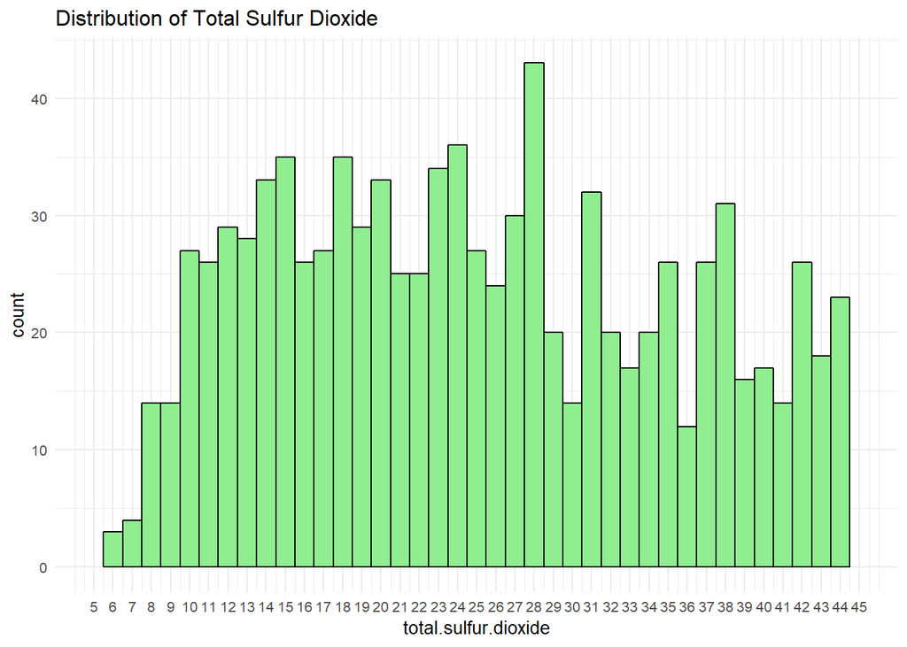

I.e between 27.5 and 28.5 values of total sulfur dioxide more wines are present

### Rescaling variables

- Skewed and long tail data can be transformed toward more normally distribution by taking square root or log function.
- Let’s look at few examples, we compare the original, square root and log of the feature.

```
##    Min. 1st Qu.  Median    Mean 3rd Qu.    Max.
##    1.00    7.00   14.00   15.87   21.00   72.00
```

```
##    Min. 1st Qu.  Median    Mean 3rd Qu.    Max.
##  0.0000  0.8451  1.1461  1.1058  1.3222  1.8573
```

```
##    Min. 1st Qu.  Median    Mean 3rd Qu.    Max.
##   1.000   2.646   3.742   3.781   4.583   8.485
```

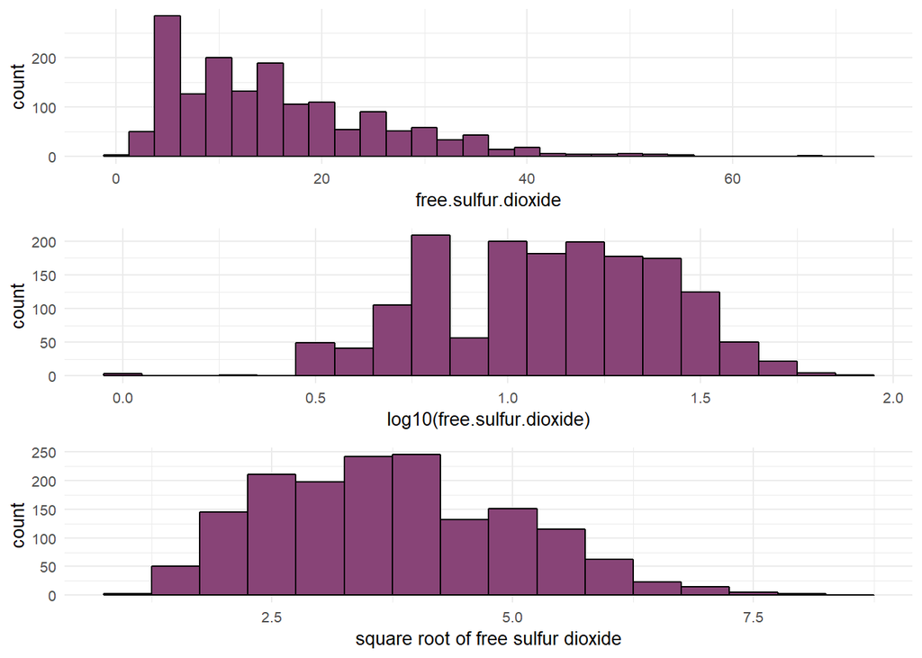

log 10 scale is having nearly normal distribution for free sulfur dioxide

```
##    Min. 1st Qu.  Median    Mean 3rd Qu.    Max.
##    6.00   22.00   38.00   46.47   62.00  289.00
```

```
##    Min. 1st Qu.  Median    Mean 3rd Qu.    Max.
##  0.7782  1.3424  1.5798  1.5638  1.7924  2.4609
```

```
##    Min. 1st Qu.  Median    Mean 3rd Qu.    Max.
##   2.449   4.690   6.164   6.434   7.874  17.000
```

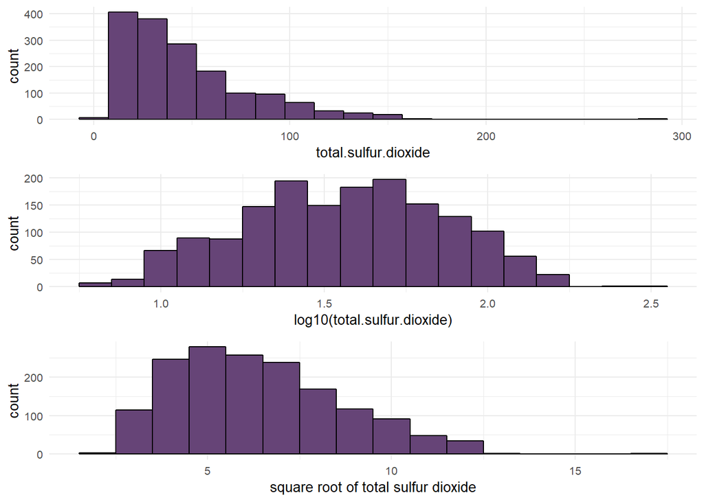

Log plot Total sulfur dioxide is normally distributed

```
##    Min. 1st Qu.  Median    Mean 3rd Qu.    Max.
##   0.000   0.090   0.260   0.271   0.420   1.000
```

```
##    Min. 1st Qu.  Median    Mean 3rd Qu.    Max.
##    -Inf -1.0458 -0.5850    -Inf -0.3768  0.0000
```

```
##    Min. 1st Qu.  Median    Mean 3rd Qu.    Max.
##  0.0000  0.3000  0.5099  0.4668  0.6481  1.0000
```

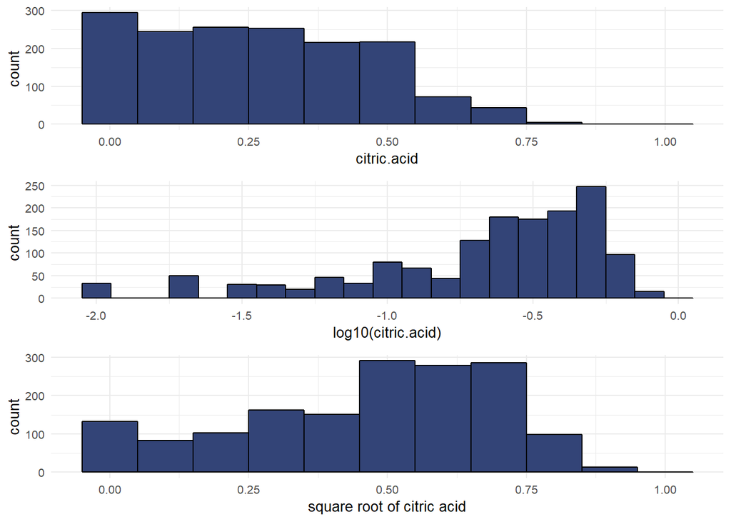

Citric acid plot has a different distribution

```
##    Min. 1st Qu.  Median    Mean 3rd Qu.    Max.
##  0.3300  0.5500  0.6200  0.6581  0.7300  2.0000
```

```
##    Min. 1st Qu.  Median    Mean 3rd Qu.    Max.
## -0.4815 -0.2596 -0.2076 -0.1934 -0.1367  0.3010
```

```
##    Min. 1st Qu.  Median    Mean 3rd Qu.    Max.
##  0.5745  0.7416  0.7874  0.8056  0.8544  1.4142
```

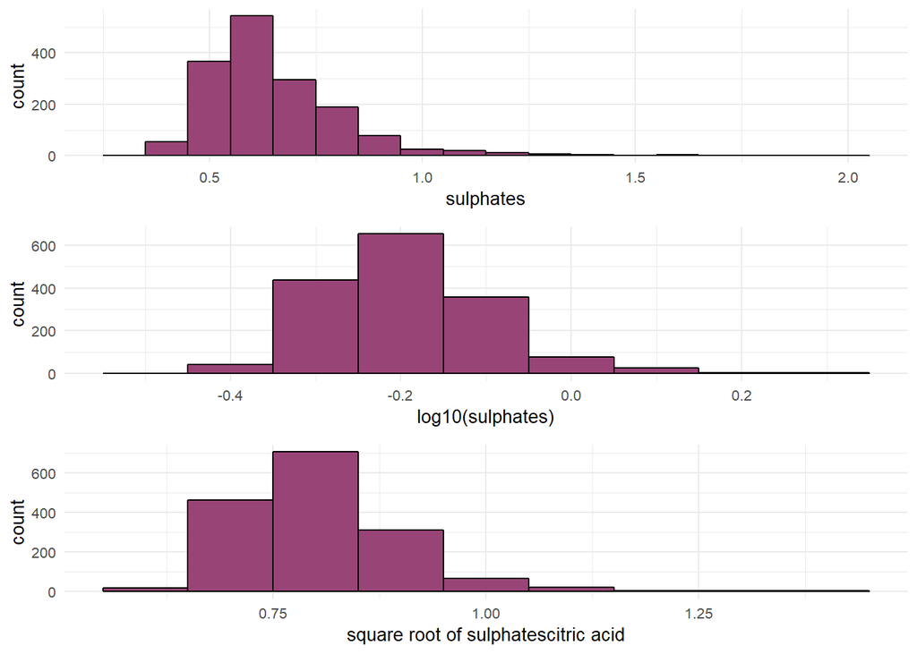

log 10 plot is having normal distribution

### What is the structure of your dataset?

This red wine quality dataset contains 1599 entries or values for the 13 different variables. 11 out of 13 variables are chemical ratios of different chemicals used in making red wine. Quality is the end result of the variables and X is an id variable. The quality variable here is an ordered factor variable, with it’s values ranging from level 3 to level 8. But quality should bfrom 0 to 10. That means in this data set 0, 1, 2, 9, 10 quality wines are not available. So most of the wines in our data set is of average quality(quality level 5 or level 6). If we consider the quality level is from 0 to 10 , then outliers doesn’t exist in the data set. As wine quality in the dataframe varies from 3 to 8. Also the dataset is a tidy dataset

### What is/are the main feature(s) of interest in your dataset?

- After reading blogs about wine , I understood that alcohol content and quality are related to each other. According to my understanding taste of the wine is important. Taste depends on many things like fixed acidity, volatile acidity, pH, citric acid. As of now I tried to understand individually the variables.

** Point of Interest **

- My main point of interest is the quality. I want to know which variables or combinations determine the quality of the wine.
- Unique features of the dataset
- Citric acid has a different distribution as compared to the other variables. When we compare the distribution of quality and distribution of citric acid, we can see that citric acid distribution is difficult to understand.

### What other features in the dataset do you think will help support your investigation into your feature(s) of interest?

- I feel following variables are helpfull in measuring the quality of wine:
- Sulphur Dioxide - Most conrtoversial and widely used additive, to protect wine from oxidation
- Citric Acid - Responsible for flavour of Wine
- Volatile Acidity - If too high can lead to unpleasant taste.

### Did you create any new variables from existing variables in the dataset?

```
## 'data.frame':    1599 obs. of  15 variables:
##  $ X                   : int  1 2 3 4 5 6 7 8 9 10 ...
##  $ fixed.acidity       : num  7.4 7.8 7.8 11.2 7.4 7.4 7.9 7.3 7.8 7.5 ...
##  $ volatile.acidity    : num  0.7 0.88 0.76 0.28 0.7 0.66 0.6 0.65 0.58 0.5 ...
##  $ citric.acid         : num  0 0 0.04 0.56 0 0 0.06 0 0.02 0.36 ...
##  $ residual.sugar      : num  1.9 2.6 2.3 1.9 1.9 1.8 1.6 1.2 2 6.1 ...
##  $ chlorides           : num  0.076 0.098 0.092 0.075 0.076 0.075 0.069 0.065 0.073 0.071 ...
##  $ free.sulfur.dioxide : num  11 25 15 17 11 13 15 15 9 17 ...
##  $ total.sulfur.dioxide: num  34 67 54 60 34 40 59 21 18 102 ...
##  $ density             : num  0.998 0.997 0.997 0.998 0.998 ...
##  $ pH                  : num  3.51 3.2 3.26 3.16 3.51 3.51 3.3 3.39 3.36 3.35 ...
##  $ sulphates           : num  0.56 0.68 0.65 0.58 0.56 0.56 0.46 0.47 0.57 0.8 ...
##  $ alcohol             : num  9.4 9.8 9.8 9.8 9.4 9.4 9.4 10 9.5 10.5 ...
##  $ quality             : int  5 5 5 6 5 5 5 7 7 5 ...
##  $ quality_fac         : Factor w/ 6 levels "3","4","5","6",..: 3 3 3 4 3 3 3 5 5 3 ...
##  $ rating              : Ord.factor w/ 3 levels "bad"<"average"<..: 2 2 2 2 2 2 2 3 3 2 ...
```

Yes, I have created quality_fac, rating. These variables helped me understand the quality of wine in detail.

### Of the features you investigated, were there any unusual distributions? Did you perform any operations on the data to tidy, adjust, or change the form of the data? If so, why did you do this?

### Yes, after creating new variables I understood that more wines are of quality level 5 and 6.

** Distribution and Outliers **

- Quality, density and pH seems normally distributed with few
- Citric acid has more values of zero also
- Looks like residual sugar and chloride have outliers.
- Fixed and volatile acidity, total and free sulfur dioxides, alcohol and sulphates are a little positively skewed
- Exactly -1. A perfect downhill (negative) linear relationship
- -0.70. A strong downhill (negative) linear relationship
- -0.50. A moderate downhill (negative) relationship
- -0.30. A weak downhill (negative) linear relationship
- 0. No linear relationship
- +0.30. A weak uphill (positive) linear relationship
- +0.50. A moderate uphill (positive) relationship
- +0.70. A strong uphill (positive) linear relationship
- Exactly +1. A perfect uphill (positive) linear relationship

```
##               fixed.acidity   quality
## fixed.acidity     1.0000000 0.1240516
## quality           0.1240516 1.0000000
```

** Correlation between fixed acidity and qulaity **

```
##
##  Pearson's product-moment correlation
##
## data:  x and y
## t = 4.996, df = 1597, p-value = 6.496e-07
## alternative hypothesis: true correlation is not equal to 0
## 95 percent confidence interval:
##  0.07548957 0.17202667
## sample estimates:
##       cor
## 0.1240516
```

We got a positive correlation of 0.12

A positive correlation, when the correlation coefficient (r) is greater than 0, signifies that both variables move in the same direction or are correlated. When r is +1, it signifies that the two variables being compared have a perfect positive relationship; when one variable moves higher or lower, the other variable moves in the same direction with the same magnitude.

Even though above correlation is positive it’s nearer to 0.1.

If the correlation coefficient of two variables is zero, it signifies that there is no linear relationship between the variables. However, this is only for a linear relationship; it is possible that the variables have a strong curvilinear relationship.

When the value of r is close to zero, generally between -0.1 and +0.1, the variables are said to have no linear relationship or a very weak linear relationship. For example, suppose the prices of coffee and of computers are observed and found to have a correlation of +.0008; this means that there is no correlation, or relationship, between the two variables.

A reading above .50 typically signals a strong positive correlation.

```r
#If Null values are present
# use cor(redwine[c("fixed.acidity", "quality")], use = "complete")
```

** Correlation between volatile acidity and quality **

```
##
##  Pearson's product-moment correlation
##
## data:  x and y
## t = -16.954, df = 1597, p-value < 2.2e-16
## alternative hypothesis: true correlation is not equal to 0
## 95 percent confidence interval:
##  -0.4313210 -0.3482032
## sample estimates:
##        cor
## -0.3905578
```

We got a negtaive correlation of -0.39

A negative correlation occurs when the correlation coefficient (r) is less than 0 and indicates that both variables move in the opposite direction. In short, any reading between 0 and -1 means that the two securities move in opposite directions. When r is -1, the relationship is said to be perfectly negative correlated; in short, if one variable increases, the other variable decreases with the same magnitude, and vice versa. However, the degree to which two securities are negatively correlated might vary over time and are almost never exactly correlated, all the time.

** Correlation between citric acidity and quality **

```
##
##  Pearson's product-moment correlation
##
## data:  x and y
## t = 9.2875, df = 1597, p-value < 2.2e-16
## alternative hypothesis: true correlation is not equal to 0
## 95 percent confidence interval:
##  0.1793415 0.2723711
## sample estimates:
##       cor
## 0.2263725
```

Correlation of + 0.226 means A weak uphill (positive) linear relationship

** Correlation between residual sugar and quality **

```
##
##  Pearson's product-moment correlation
##
## data:  x and y
## t = 0.5488, df = 1597, p-value = 0.5832
## alternative hypothesis: true correlation is not equal to 0
## 95 percent confidence interval:
##  -0.03531327  0.06271056
## sample estimates:
##        cor
## 0.01373164
```

Almost zero correlation(0.0137)

That means No linear relationship`

** Correlation between chlorides and quality **

```
##
##  Pearson's product-moment correlation
##
## data:  x and y
## t = -5.1948, df = 1597, p-value = 2.313e-07
## alternative hypothesis: true correlation is not equal to 0
## 95 percent confidence interval:
##  -0.17681041 -0.08039344
## sample estimates:
##        cor
## -0.1289066
```

Negative correlation of -0.12 almost equal to zero.

That means No linear relationship

** Correlation between free sulphur dioxide and quality **

```
##
##  Pearson's product-moment correlation
##
## data:  x and y
## t = -2.0269, df = 1597, p-value = 0.04283
## alternative hypothesis: true correlation is not equal to 0
## 95 percent confidence interval:
##  -0.099430290 -0.001638987
## sample estimates:
##         cor
## -0.05065606
```

Almost zero correlation(-0.05)

That means No linear relationship

** Correlation between total sulphur dioxide and quality **

```
##
##  Pearson's product-moment correlation
##
## data:  x and y
## t = -7.5271, df = 1597, p-value = 8.622e-14
## alternative hypothesis: true correlation is not equal to 0
## 95 percent confidence interval:
##  -0.2320162 -0.1373252
## sample estimates:
##        cor
## -0.1851003
```

** Correlation between density and quality **

```
##
##  Pearson's product-moment correlation
##
## data:  x and y
## t = -7.0997, df = 1597, p-value = 1.875e-12
## alternative hypothesis: true correlation is not equal to 0
## 95 percent confidence interval:
##  -0.2220365 -0.1269870
## sample estimates:
##        cor
## -0.1749192
```

** Correlation between ph and quality **

```
##
##  Pearson's product-moment correlation
##
## data:  x and y
## t = -2.3109, df = 1597, p-value = 0.02096
## alternative hypothesis: true correlation is not equal to 0
## 95 percent confidence interval:
##  -0.106451268 -0.008734972
## sample estimates:
##         cor
## -0.05773139
```

Almost zero correlation(-0.057)

That means No linear relationship

** Correlation between sulphates and quality **

```
##
##  Pearson's product-moment correlation
##
## data:  x and y
## t = 10.38, df = 1597, p-value < 2.2e-16
## alternative hypothesis: true correlation is not equal to 0
## 95 percent confidence interval:
##  0.2049011 0.2967610
## sample estimates:
##       cor
## 0.2513971
```

Positive correlation(0.251)

A weak uphill (positive) linear relationship

** Correlation between alcohol and quality **

```
##
##  Pearson's product-moment correlation
##
## data:  x and y
## t = 21.639, df = 1597, p-value < 2.2e-16
## alternative hypothesis: true correlation is not equal to 0
## 95 percent confidence interval:
##  0.4373540 0.5132081
## sample estimates:
##       cor
## 0.4761663
```

- Positive Correlation of 0.476
- A moderate uphill (positive) relationship

** The function ggpairs() produces a matrix of scatter plots for visualizing the correlation between variables. **

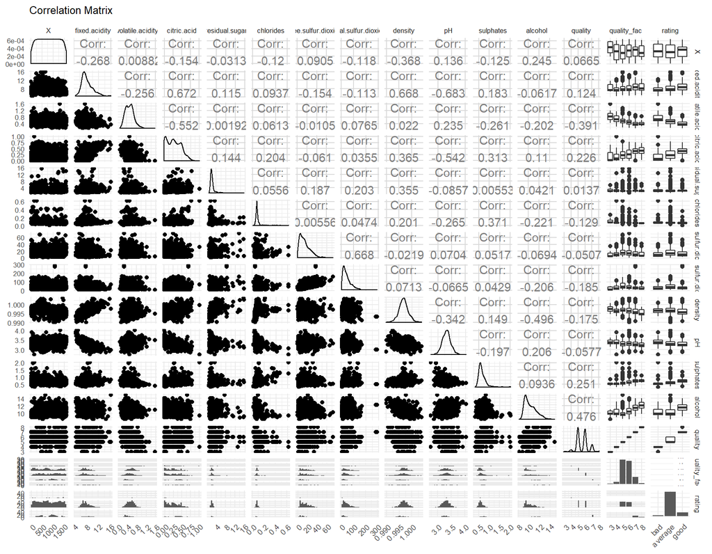

** After observing above correlation matrix **

- Quality vs other chemical components
- Correlation above 0.2 is there for volatile.acidity, citric.acid, sulphates, alcohol
- quality vs volatile.acidity -0.391
- quality vs citric.acid 0.226
- quality vs sulphates 0.251
- quality vs alcohol 0.476

** Comparing other chemical components for correlation (For above 0.2 correlation) **

- Alcohol vs density, chlorides, total sulfur dioxide, volatile acidity
- Alcohol vs density -0.496
- Alcohol vs chlorides -0.221
- Alcohol vs total sulfur dioxide -0.206
- Alcohol vs volatile.acidity -0.202
- Sulphates vs citric acid, chlorides, volatile.acidity
- Sulphates vs citric acid 0.313
- Sulphates vs chlorides 0.371
- Sulphates vs volatile.acidity -0.261
- pH vs fixed.acidity, citric acid, chlorides, density
- pH vs fixed.acidity -0.683
- pH vs volatile.acidity 0.235
- pH vs citric acid -0.542
- pH vs chlorides -0.265
- pH vs density -0.342
- density vs fixed.acidity, residualsugar, citric acid
- density vs fixed.acidity 0.668
- density vs residualsugar 0.355
- density vs citric acid 0.365
- Total sulfur dioxide vs volatile sulfur dioxide
- 0.668
- Citric acid vs fixed acidity and volatile acidity
- Citric acid vs fixed acidity 0.672
- Citric acid vs volatile acidity -0.552

** After comparing above strong correlation is there in between following ** * quality vs alcohol 0.476 * Alcohol vs density -0.496 * density vs fixed.acidity 0.668 * fixed.acidity vs pH -0.683 * pH vs citric acid -0.542 * Citric acid vs fixed acidity 0.672 * Citric acid vs volatile acidity -0.552

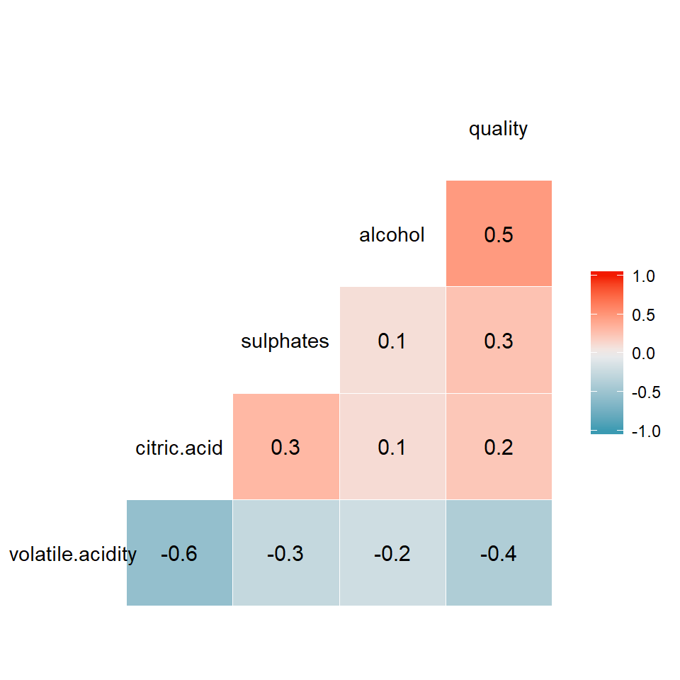

Only 3 correlations are greater than 0.3

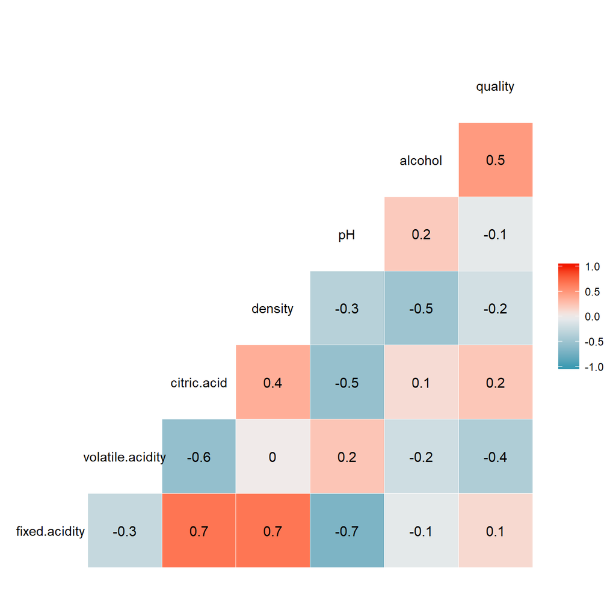

Above I want to add fixed acidity and volatile acidity as total and see the trends

Afrer comparison, If acidity is a single variable, we can draw conclusions easily. So I want to create a new variable called total.acidity( combining fixed and volatile) And I want to create another variable named combined sulfur dioxide, which is the difference between total sulfur and free sulfur

### With new variables

The function ggpairs() produces a matrix of scatter plots for visualizing the correlation between variables.

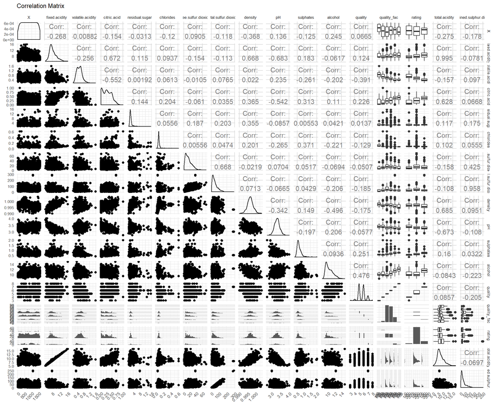

** After observing above correlation matrix **

- Quality vs other chemical components
- Correlation above 0.2 is there for volatile.acidity, citric.acid, sulphates, alcohol, combined sulfur dioxide
- quality vs volatile.acidity -0.391
- quality vs citric.acid 0.226
- quality vs sulphates 0.251
- quality vs alcohol 0.476
- quality vs combined sulfur dioxide -0.205

** Comparing other chemical components for correlation (For above 0.2 correlation) **

- Alcohol vs density, chlorides, total sulfur dioxide
- Alcohol vs density -0.496
- Alcohol vs chlorides -0.221
- Alcohol vs total sulfur dioxide -0.206
- Alcohol vs combined sulfur dioxide -0.223
- Sulphates vs citric acid, chlorides
- Sulphates vs citric acid 0.313
- Sulphates vs chlorides 0.371
- pH vs total acidity, citric acid, chlorides, density
- pH vs citric acid -0.542
- pH vs chlorides -0.265
- pH vs density -0.342
- pH vs total acidity -0.673
- density vs total acidity, residualsugar, citric acid
- density vs residualsugar 0.355
- density vs citric acid 0.365
- density vs total acidity 0.685
- Total sulfur dioxide vs volatile sulfur dioxide
- 0.668
- Citric acid vs total acidity
- citric acid vs total acidity 0.628

After comparing above strong correlation is there in between following

- Quality vs alcohol 0.476
- Alcohol vs density -0.496
- density vs total.acidity 0.685
- Total.acidity vs pH -0.673
- pH vs citric acid -0.542
- Citric acid vs total acidity 0.628

So above 6 variables are correlated strongly

```
##        X          fixed.acidity   volatile.acidity  citric.acid
##  Min.   :   1.0   Min.   : 4.60   Min.   :0.1200   Min.   :0.000
##  1st Qu.: 400.5   1st Qu.: 7.10   1st Qu.:0.3900   1st Qu.:0.090
##  Median : 800.0   Median : 7.90   Median :0.5200   Median :0.260
##  Mean   : 800.0   Mean   : 8.32   Mean   :0.5278   Mean   :0.271
##  3rd Qu.:1199.5   3rd Qu.: 9.20   3rd Qu.:0.6400   3rd Qu.:0.420
##  Max.   :1599.0   Max.   :15.90   Max.   :1.5800   Max.   :1.000
##  residual.sugar     chlorides       free.sulfur.dioxide
##  Min.   : 0.900   Min.   :0.01200   Min.   : 1.00
##  1st Qu.: 1.900   1st Qu.:0.07000   1st Qu.: 7.00
##  Median : 2.200   Median :0.07900   Median :14.00
##  Mean   : 2.539   Mean   :0.08747   Mean   :15.87
##  3rd Qu.: 2.600   3rd Qu.:0.09000   3rd Qu.:21.00
##  Max.   :15.500   Max.   :0.61100   Max.   :72.00
##  total.sulfur.dioxide    density             pH          sulphates
##  Min.   :  6.00       Min.   :0.9901   Min.   :2.740   Min.   :0.3300
##  1st Qu.: 22.00       1st Qu.:0.9956   1st Qu.:3.210   1st Qu.:0.5500
##  Median : 38.00       Median :0.9968   Median :3.310   Median :0.6200
##  Mean   : 46.47       Mean   :0.9967   Mean   :3.311   Mean   :0.6581
##  3rd Qu.: 62.00       3rd Qu.:0.9978   3rd Qu.:3.400   3rd Qu.:0.7300
##  Max.   :289.00       Max.   :1.0037   Max.   :4.010   Max.   :2.0000
##     alcohol         quality      quality_fac     rating
##  Min.   : 8.40   Min.   :3.000   3: 10       bad    :  63
##  1st Qu.: 9.50   1st Qu.:5.000   4: 53       average:1319
##  Median :10.20   Median :6.000   5:681       good   : 217
##  Mean   :10.42   Mean   :5.636   6:638
##  3rd Qu.:11.10   3rd Qu.:6.000   7:199
##  Max.   :14.90   Max.   :8.000   8: 18
##  total.acidity    combined.sulphur.dioxide
##  Min.   : 5.120   Min.   :  3.00
##  1st Qu.: 7.680   1st Qu.: 12.00
##  Median : 8.445   Median : 21.00
##  Mean   : 8.847   Mean   : 30.59
##  3rd Qu.: 9.740   3rd Qu.: 39.00
##  Max.   :16.285   Max.   :251.50
```

According to New Redwine set( Including two newly created variables) below 6 variables are correlated strongly.

Quality, alcohol, density, total.acidity, pH, citric acid

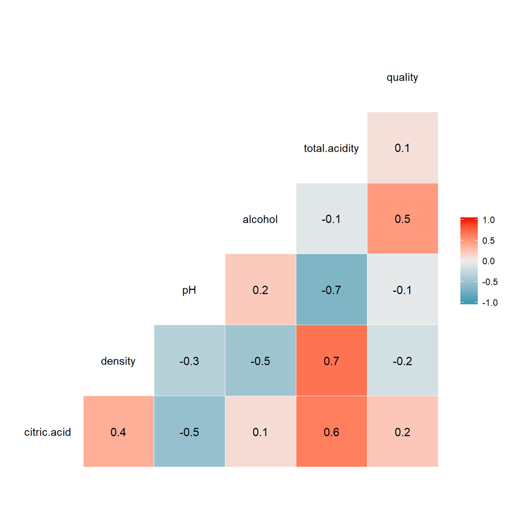

Above are The factors correlated with the wine quality

I want to consider a correlation of min 0.5(positive or negative)

### Part A

For the original dataset redwine, correlation is strong for (quality vs other variables)

Correlation above 0.2 is there for volatile.acidity, citric.acid, sulphates, alcohol

### Part B

According to Redwine set( original) 7 variables are correlated strongly.

Quality, alcohol, density, fixed.acidity, pH, citric acid,, volatile acidity

### Part C

According to New Redwine set( Including two newly created variables) below 6 variables are correlated strongly.

Quality, alcohol, density, total.acidity, pH, citric acid

As quality is the main factor, I want to see the pattern in part A plots

After comparing above B&C, I want to consider the new redwine dataset, because it has total acidity(fixed acidity + volatile acidity)

```r
# You can use also subset
#df4 <- subset(redwine, select = c("fixed.acidity","volatile.acidity","citric.acid",
#                              "density" , "pH", "alcohol", "quality"))
#ggcorr(df4, palette = "RdBu", label = TRUE)
```